# A tutorial for constructing a GMD-biplot

Yue Wang

## Introduction

In this vignette, we illustrate how to construct the GMD-biplot and screeplot using the tobacco data set from (Satten et al. 2017). This data set includes 15 smokeless tobacco products: 6 dry snuffs, 7 moist snuffs, and 2 toombak samples from Sudan. Three separate (replicate) observations (starting with sample preparation) were made of each product, so that in total 45 observations are available. Each observation has a 271 × 1 vector of taxon counts. To make the measurements comparable, we consider the centered log ratio (CLR) transformation of the data set. Additionally, the squared weighted UniFrac distance, denoted $\Delta$, is used to measure the distance between samples. The corresponding similarity kernel $H$ is derived from $\Delta$ using the Gower’s centering matrix.

## Step 1: Loading the tobacco data set

We first load our R package **GMDecomp**.

```r
library(GMDecomp)
```

The data object **tobacco_clr** in the package include

- data: the CLR transformed out table, with rows for samples and columns for OTU.
- $H$: the similarity kernel derived from the squared weighted UniFrac distance.
- sample.col: the color for plotting each sample point.
- sample.pch: the shape for plotting each sample point.
- out.names: the taxonomic name of each OTU.

## Step 2: Generalized Matrix Decomposition

To construct the GMD-biplot and screeplot, we need to first perform the generalized matrix decomposition (Allen, Grosenick, and Taylor 2014) of the data with respect to $H$. This can be easily achieved using the following line:

```r
tobacco.gmd <- GMD(X = tobacco_clr$data, H = tobacco_clr$H, Q = diag(1, dim(tobacco_clr$data)[2]), K = 10)
```

Note that here we don’t have a similarity kernel for the OTUs, so $Q$ is set to be an identity matrix. One can set $Q$ to be any informative positive semi-definite matrix, if such information is available. Also, here we set $K = 10$, since we want to display the screeplot the top 10 GMD components. If only the GMD-biplot is needed, one can set $K = 2$, which may save computational time.

**tabacco.gmd** is a list of class **gmd**, which consists of the following variables.

- U: the left GMD components with 45 rows and 10 columns.
- S: the top 10 GMD values.
- V: the right GMD components with 271 rows and 10 columns.
- H: the similarity matrix for samples.
- Q: the similarity matrix for OTUs.

## Step 3: The GMD-biplot and screeplot

Once the GMD outputs are obtained, the screeplot can by easily constructed as follows.

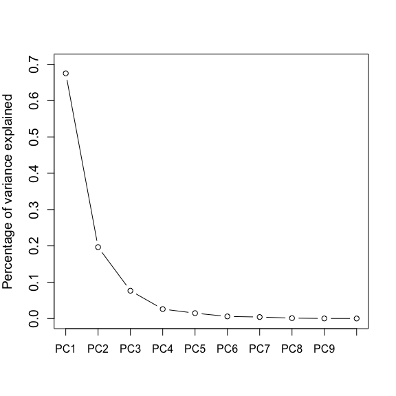

```r
screeplot(tobacco.gmd) #the screeplot of the top 10 GMD components
```

Note that one can select specific OTUs to display in the GMD-biplot. For this analysis, we display the top 3 OTUs that have the longest arrows.

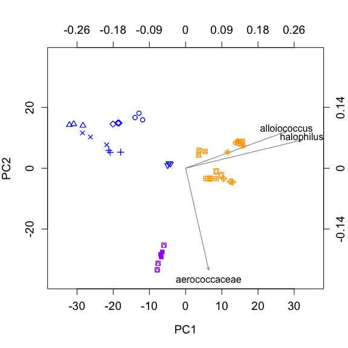

```r
gmd.order = order(rowSums(tobacco.gmd$V[,1:2]^2), decreasing = T)
plot.index = gmd.order[1:3]
plot.names = tobacco_clr$otu.names[plot.index]
biplot(fit = tobacco.gmd, index = plot.index, names = plot.names, sample.col = tobacco_clr$sample.color, sample.pch = tobacco_clr$sample.pch, arrow.col = 'grey50')
```

## References

Allen, Genevera I., Logan Grosenick, and Jonathan Taylor. 2014. “A Generalized Least-Square Matrix Decomposition.” *Journal of the American Statistical Association* 109 (505). Taylor & Francis: 145–59.

Satten, G. A., R. E. Tyx, A. J. Rivera, and S. Stanfill. 2017. “Restoring the Duality between Principal Components of a Distance Matrix and Linear Combinations of Predictors, with Application to Studies of the Microbiome.” *PLoS ONE* 12 (1).